# Datenanalyse - ein erstes Beispiel

Manfred Brill

# 1 Erste Schritte bei der Datenanalyse mit R

Wir betrachten die folgenden Themen:

- Angaben zum Datensatz, Dokumentation, Quellenangaben. Falls bekannt auch schon die Spalten und ihre Bedeutung beschreiben.
- Thesen formulieren, die wir an Hand der Daten überprüfen. Sonst finden wir nur Dinge, die in den Daten enthalten sind.
- Importieren als csv-Datei, wie gehen wir mit fehlenden Einträgen um
- Verändern der Daten, so dass wir besser damit umgehen können. Das kann bedeuten, dass wir Spalten streichen, dass wir neue erzeugen oder auch wie im betrachteten Beispiel, dass wir Einheiten oder andere Dinge umrechnen, um die Interpretation zu vereinfachen. Wir überprüfen auch die Datentypen der Spalten, insbesondere achten wir darauf, dass qualitative oder ordinale Daten als Typ *factor* behandelt wird.
- Exploration der Daten - Berechnung von Kennzahlen, Häufigkeiten, insbesondere Visualisierungen, auch von Zusammenhängen.
- Wir diskutieren die Thesen an Hand der Daten, wir stellen eventuell auch neue auf, da wir Strukturen oder Abhängigkeiten in den Daten gefunden haben.

# 2 Der Datensatz

Die Daten stammen aus von der Website zu (James et al. 2023). Es gibt auch ein Package mit den Datensätzen für R. Die hier verwendete Version wird im Buch verwendet, um zu zeigen wie wir mit fehlenden Einträgen umgehen. Im Buch wird ein ASCII-File eingelesen, wir verwenden eine csv-Datei, die aus dieser Datei erstellt wurde.

Wir erhalten Daten über 397 Automodelle und 9 Attribute für jedes Modell:

- mpg gibt die miles per gallon, also den Verbrauch des Weagen, an.
- cylinders enthzält Angaben über die Anzahl der Zylinder
- displacement ist der englische Ausdruck für Hubraum.
- horsepower gibt die Anzahl der PS des Autos an.
- weight ist das Gewicht des Autos
- acceleration ist die Zeit für die Beschleunigung.
- year ist das Modelljahr des Autos
- origin kodiert mit Hilfe von natürlich Zahlen den Ursprung des Autos, also USA, Europa oder Japan.
- name ist die Bezeichnung des Automodells.

Wir werden auf die verwendeten Einheiten noch weiter unten eingehen.

# 3 Thesen und Vermutungen

Interssant ist natürlich der Verbrauch der enthaltenen Automodelle.

- Die Leistung in PS wird für immer größeren Hubraum ebenfalls größer.
- Der Verbrauch sollte von Attributen wie Herkunftsland, Anzahl der Zylinder oder PS-Angaben abhängen.
- Interessant ist auch die Frage, ob der Verbrauch oder andere Attribute wie Anzahl der Zylinder oder Hubraum sich im Laufe der Jahre verändert.

# 4 Daten importieren

Wir verwenden eine csv-Version der Datei, die auf der Website des Buchs zu finden ist. Wir stellen sicher, dass die Datei im Verzeichnis enthalten ist, in dem wir nach Datensätzen suchen.

Bevor wir die Daten einlesen öffnen wir die csv-Datei in einem ASCII-Editor. Wir sehen, dass die erste Zeile Überschriften enthält, die wir bereits in der Beschreibung der Daten notiert hatten. Die Spalten sind mit einem Komma getrennt, was bei Daten aus dem angelsächsischen Raum häufig auftrett. Das bedeutet, dass der Punkt hier als Dezimalpunkt zu interpretieren ist.

Wir verwenden die Funktion *read_csv* aus Tidyverse. Die Option *col_names* sorgt dafür, dass die erste Zeile als Spalten-Überschriften interpretiert werden. Nach dem Import zeigt *read_csv* die Typen, die beim Import für die einzelnen Spalten gesetzt wurden. Das können wir mit *show_col_types* auch unterdrücken. Die Datentypen für die Spalten werden, wenn wir sie nicht explizit angeben, aus den ersten 100 Zeilen geschätzt. Die Bezeichnung *NA* steht für **not available**. Damit sind fehlende Einträge gemeint. Fehlende Werte sind in der Praxis häufig ein Problem. Wir können mit der übergebenen Liste angeben, wie in den importierten Daten fehlende Einträge gekénnzeichnet sind. Die ersten beiden Zeichen in der Liste *NA* sind der Default. Aus dem Buch wissen wir, dass fehlende Einträge enthalten sind, die hier mit einem *?* gekennzeichnet sind, so dass wir dieses Zeichen bei der Option *na* mit übernehmen.

```r
car <- read_csv("../data/Auto.csv",
                col_names=TRUE,
                show_col_types=FALSE,
                na=c(" ", "NA", "?"))
```

## 4.1 Prüfen des Imports

Wir überzeugen uns, dass wir die angegebene Anzahl von Zeilen und Spalten eingelesen haben und geben den Beginn des Tibbles *car* auf der Konsole aus.

```r
nrow(car)
```

```
[1] 397
```

```r
ncol(car)
```

```
[1] 9
```

Die ausgegebenen Zahlen passen auf die Angaben. Jetzt geben wir den Anfang der Daten aus.

```r
car
```

| mpg | cylinders | displacement | horsepower | weight | acceleration | year | origin | name |
| --- | --- | --- | --- | --- | --- | --- | --- | --- |
| 18.0 | 8 | 307.0 | 130 | 3504 | 12.0 | 70 | 1 | chevrolet chevelle malibu |
| 15.0 | 8 | 350.0 | 165 | 3693 | 11.5 | 70 | 1 | buick skylark 320 |
| 18.0 | 8 | 318.0 | 150 | 3436 | 11.0 | 70 | 1 | plymouth satellite |
| 16.0 | 8 | 304.0 | 150 | 3433 | 12.0 | 70 | 1 | amc rebel sst |
| 17.0 | 8 | 302.0 | 140 | 3449 | 10.5 | 70 | 1 | ford torino |
| 15.0 | 8 | 429.0 | 198 | 4341 | 10.0 | 70 | 1 | ford galaxie 500 |
| 14.0 | 8 | 454.0 | 220 | 4354 | 9.0 | 70 | 1 | chevrolet impala |
| 14.0 | 8 | 440.0 | 215 | 4312 | 8.5 | 70 | 1 | plymouth fury iii |
| 14.0 | 8 | 455.0 | 225 | 4425 | 10.0 | 70 | 1 | pontiac catalina |
| 15.0 | 8 | 390.0 | 190 | 3850 | 8.5 | 70 | 1 | amc ambassador dpl |

[output cut: 387 more lines]

Wir erhalten nochmals die Angaben über die Anzahl von Zeilen und Spalten. Wichtig für uns sind die angegebenen Datentypen. Wir hätten die Typen die wir uns wünschen bereits beim Einlesen spezifizieren können. Da wir weiter unten aber auch Einheiten umrechnen und die Reihenfolge der Spalten verändern werden haben wir darauf verzichtet.

Aus dem ISLR-Buch ist bekannt, dass es Einträge gibt, die mit einem Fragezeichen gekennzeichnet sind, da hier Werte fehlen. Aus dieem Grund wurde bei der Funktion *read_csv* das Fragezeichen in die Liste für das Attribut *na* aufgenommen ersetzt. D Die Abkürzung *na* steht für *not available*. Nach dem Import finden wir solche Einträge im Tibble *car* als *NA*. Falls wir nicht wissen ob solche Einträge vorhanden sind setzen wir die Funktion *anyNY* einn, die in unserem Fall natürlich *TRUE* zurückgibt.

```r
anyNA(car)
```

```
[1] TRUE
```

Wenn wir etwas genauer in der Ausgabe des Tibble sehen erkennen wir, dass die Fragezeichen immer in der Spalte *horsepower* enthalten sind. Wir lassen uns die Zeilen ausgeben, in denen *NA* enthalten ist. Wir hätten auch *summarise* verwenden und nur die Anzahl dieser Zeilen bestimmen können.

```r
narows <- car %>%
  filter(is.na(horsepower))

kable(narows,
      align="l",
      caption="Tabelle 1: Die Zeilen im Datensatz mit NA-Einträgen") %>%
      kable_styling(bootstrap_options = c("striped", "condensed"),
                full_width = T,
                position = "center")
```

Tabelle 1: Die Zeilen im Datensatz mit NA-Einträgen

| mpg | cylinders | displacement | horsepower | weight | acceleration | year | origin | name |
| --- | --- | --- | --- | --- | --- | --- | --- | --- |
| 25.0 | 4 | 98 | NA | 2046 | 19.0 | 71 | 1 | ford pinto |
| 21.0 | 6 | 200 | NA | 2875 | 17.0 | 74 | 1 | ford maverick |
| 40.9 | 4 | 85 | NA | 1835 | 17.3 | 80 | 2 | renault lecar deluxe |
| 23.6 | 4 | 140 | NA | 2905 | 14.3 | 80 | 1 | ford mustang cobra |
| 34.5 | 4 | 100 | NA | 2320 | 15.8 | 81 | 2 | renault 18i |

Für bessere Lesbarkeit der Ausgabe verwenden wir die Funktion *kable*. Es gibt insgesamt 5 Zeilen. In unserem Fall verzichten wir darauf, einen Versuch zu unternehmen, die fehlenden Werte zu korrigieren oder durch andere Methoden durch sinnvolle Einträge zu ersetzen. Wir löschen die 5 Zeilen mit Hilfe der Funktion *is.na* und *filter*:

```r
car <- car %>%
  filter(!is.na(horsepower))

nrow(car)
```

```
[1] 392
```

Wir geben zur Sicherheit die Anzahl der jetzt noch enthaltenen Zeilen auf der Konsole aus. Jetzt liegen noch 392 Zeilen vor. Dieses *tibble* entspricht jetzt dem Datensatz, den wir als Datensatz *Auto* im Package *ISLR* direkt einlesen können.

# 5 Anpassungen im Datensatz

Einige der Spalten sind Faktoren, was beim Einlesen allerdings noch nicht gesetzt wurde. Das führen wir jetzt durch, denn mit dem Datentyp *factor* sind Grafiken mit *ggplot2* häufig sehr viel einfacher zu realisieren. Dabei werden wir auch die Namen der spalten verändern und deutsche Begriffe einführen. Es ist ok, dass die Region, aus der das Auto stammt mit Zahlen 1, 2 und 3 codiert sind. Dies werden wir zu einem Faktor machen und Strings für die drei Regionen verwenden.

Die Interpretation einiger Spalten wie *displacement* könnte uns allerdings schwer fallen. Und wir denken nicht in Gallonen pro 100 Meilen als Verbrauch, sondern in Europa wird der durschnittliche Verbrauch in Liter pro 100 Kilometer angegeben. Aus diesem Grund wandeln wir alle Einheiten im Datensatz in metrische Angaben um.

Das ganze führen wir mit einer Pipeline durch, erzeugen die neuen Spalten und löschen ganz am Ende mit *select* die alten Einträge, da wir sie nicht mehr benötigen. Als Vorbereitung definieren wir einige Konstanten für die Umrechnung der Einheiten.

```r
hp2PS <- 1.0/0.986
mpg2kmh <- 235.0
cuin2l <- 1.0/61.0237
lbs2kg <- 1.0/2.20423
```

Das neue Tibble nennen wir *Auto*. Die Umwandlung der Zahlencodes für die Region führen wir mit *recode* in einem Aufruf der Funktion *mutate* durch. Aus den zweistelligen Jahresangaben machen wir vierstellige Angaben Dann verändern wir die Einträge, die nicht-metrische Einheiten verwenden.

```r
Auto <- car %>%
  mutate(Region = recode(origin, `1`= "USA", `2` = "Europa", `3` = "Japan"),
         year = 1900 + year,
         mpg = mpg2kmh/mpg,
         displacement = cuin2l*displacement,
         horsepower = hp2PS*horsepower,
         weight = lbs2kg*weight/1000.0
         ) %>%
  select(
    Name = name,
    Region,
    Baujahr = year,
    Zylinder = cylinders,
    Hubraum = displacement,
    Gewicht = weight,
    Verbrauch = mpg,
    PS = horsepower,
    Beschleunigung = acceleration
  )
```

Nach der Funktion *mutate* wählen wir mit *select* die Spalten aus, die wir jetzt verwenden möchten und geben dabei auch gleich neue Bezeichner an. wir verändern auch die Reihenfolge der Spalten, es macht viel mehr Sinn die Bezeichnung des Modells in der ersten Spalte zu haben.

Es fehlt noch, die neuen Spalten *Region*, *Zylinder* und *Baujahr* in den Datentyp *factor* zu casten:

```r
Auto$Region <- as_factor(Auto$Region)
Auto$Zylinder <- as_factor(Auto$Zylinder)
Auto$Baujahr <- as_factor(Auto$Baujahr)
```

Die ersten sechs Zeilen des überarbeitete Datensatzes sind in der folgenden Tabelle zu sehen, die wir wieder mit *kable* ausgeben.

| Name | Region | Baujahr | Zylinder | Hubraum | Gewicht | Verbrauch | PS | Beschleunigung |
| --- | --- | --- | --- | --- | --- | --- | --- | --- |
| chevrolet chevelle malibu | USA | 1970 | 8 | 5.03 | 1.59 | 13.1 | 132 | 12.0 |
| buick skylark 320 | USA | 1970 | 8 | 5.74 | 1.68 | 15.7 | 167 | 11.5 |
| plymouth satellite | USA | 1970 | 8 | 5.21 | 1.56 | 13.1 | 152 | 11.0 |
| amc rebel sst | USA | 1970 | 8 | 4.98 | 1.56 | 14.7 | 152 | 12.0 |
| ford torino | USA | 1970 | 8 | 4.95 | 1.56 | 13.8 | 142 | 10.5 |
| ford galaxie 500 | USA | 1970 | 8 | 7.03 | 1.97 | 15.7 | 201 | 10.0 |

# 6 Datenexploration

Wir werden keine vollständige Exploration der Daten durchführen, aber wir werden hier die Daten in einer interaktiven Tabelle ausgeben, einige Häufigkeiten bestimmen und insbesondere Grafiken erzeugen.

Dazu setzen wir HTMLWidgets ein, die im Ergebnis Widgets erzeugen, die mit dem eingebetten JavaScript-Code Interaktivität erzeugen.

## 6.1 Datentabellen

Wir verwenden die Library *DT* und die darin enthaltene Funktion *datatable*.

```r
datatable(Auto,
          options = list(pageLength = 5))
```

|  | Name | Region | Baujahr | Zylinder | Hubraum | Gewicht | Verbrauch | PS | Beschleunigung |
| --- | --- | --- | --- | --- | --- | --- | --- | --- | --- |
| 1 | chevrolet chevelle malibu | USA | 1970 | 8 | 5.03083228319489 | 1.58967076938432 | 13.0555555555556 | 131.84584178499 | 12 |
| 2 | buick skylark 320 | USA | 1970 | 8 | 5.735476544359 | 1.67541499752748 | 15.6666666666667 | 167.342799188641 | 11.5 |
| 3 | plymouth satellite | USA | 1970 | 8 | 5.21109011744617 | 1.55882099417937 | 13.0555555555556 | 152.129817444219 | 11 |
| 4 | amc rebel sst | USA | 1970 | 8 | 4.98167105567181 | 1.55745997468504 | 14.6875 | 152.129817444219 | 12 |
| 5 | ford torino | USA | 1970 | 8 | 4.94889690398976 | 1.5647187453215 | 13.8235294117647 | 141.987829614604 | 10.5 |
| 6 | ford galaxie 500 | USA | 1970 | 8 | 7.03005553580003 | 1.96939520830403 | 15.6666666666667 | 200.811359026369 | 10 |
| 7 | chevrolet impala | USA | 1970 | 8 | 7.43973243182567 | 1.97529295944616 | 16.7857142857143 | 223.123732251521 | 9 |
| 8 | plymouth fury iii | USA | 1970 | 8 | 7.21031337005131 | 1.95623868652545 | 16.7857142857143 | 218.052738336714 | 8.5 |
| 9 | pontiac catalina | USA | 1970 | 8 | 7.45611950766669 | 2.00750375414544 | 16.7857142857143 | 228.194726166329 | 10 |
| 10 | amc ambassador dpl | USA | 1970 | 8 | 6.39095957800002 | 1.74664168439773 | 15.6666666666667 | 192.697768762677 | 8.5 |

[output cut: 382 more lines]

Diese Darstellung ist später in Dashboards sehr nützlich, denn wir können suchen und in den Zeilen die Werte durchscrollen. Die große Anzahl der Nachkommastellen ist durch unsere Umrechnung entstanden. Wir erzeugen für die Tabelle eine Version unseres Tibble, das weniger Stellen nach dem Komma enthält und damit in der Darstellung übersichtlicher wird.

```r
numberOfDigits <- 3
AutoLessDigits <- Auto %>%
  mutate(across(is.numeric, round, digits = numberOfDigits))
datatable(AutoLessDigits,
          options = list(pageLength = 5))
```

|  | Name | Region | Baujahr | Zylinder | Hubraum | Gewicht | Verbrauch | PS | Beschleunigung |
| --- | --- | --- | --- | --- | --- | --- | --- | --- | --- |
| 1 | chevrolet chevelle malibu | USA | 1970 | 8 | 5.031 | 1.59 | 13.056 | 131.846 | 12 |
| 2 | buick skylark 320 | USA | 1970 | 8 | 5.735 | 1.675 | 15.667 | 167.343 | 11.5 |
| 3 | plymouth satellite | USA | 1970 | 8 | 5.211 | 1.559 | 13.056 | 152.13 | 11 |
| 4 | amc rebel sst | USA | 1970 | 8 | 4.982 | 1.557 | 14.688 | 152.13 | 12 |
| 5 | ford torino | USA | 1970 | 8 | 4.949 | 1.565 | 13.824 | 141.988 | 10.5 |
| 6 | ford galaxie 500 | USA | 1970 | 8 | 7.03 | 1.969 | 15.667 | 200.811 | 10 |
| 7 | chevrolet impala | USA | 1970 | 8 | 7.44 | 1.975 | 16.786 | 223.124 | 9 |
| 8 | plymouth fury iii | USA | 1970 | 8 | 7.21 | 1.956 | 16.786 | 218.053 | 8.5 |
| 9 | pontiac catalina | USA | 1970 | 8 | 7.456 | 2.008 | 16.786 | 228.195 | 10 |
| 10 | amc ambassador dpl | USA | 1970 | 8 | 6.391 | 1.747 | 15.667 | 192.698 | 8.5 |

[output cut: 382 more lines]

## 6.2 Grafiken

Für die grafische Ausgaben setzen wir *ggplot2* ein. Wir hatten bei der beschreibenden Statistik bereits Balkendiagramme für relative Häufigkeiten erzeugt. Hier gibt es seit der Version 3.4.1 von *ggplot2* eine Änderung. Wir müssen nun die Funktion *after_stat* einsetzen statt der alten Notation *y = ..prop..*. Und wir müssen angeben, dass die Daten nach den Einträgen gruppiert werden, da die Funktion *prop* gruppenweise zählt. Das Ergebnis ist das bekannte aus der Statistik.

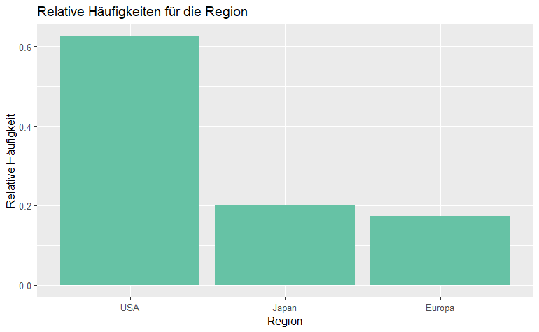

```r
ggplot(Auto) +
  geom_bar(mapping=aes(x =  Region,
                       y = after_stat(prop),
                       group = TRUE),
                       fill = myPalette[1]) +
  labs(
    title="Relative Häufigkeiten für die Region",
    x = "Region",
    y = "Relative Häufigkeit"
  )
```

Über 60 % der Einträge stammen von US-amerikanischen Autos. Der Anteil von Modellen aus Japan oder Europa ist ziemlich gleich.

Wir hatten schon die These aufgestellt, dass der Verbrauch von der Region abhängt. Das überprüfen wir mit Hilfe eines Box-Plots. Dabei erzeugen wir für jede Region eine Box, so dass wir die These gut überprüfen können.

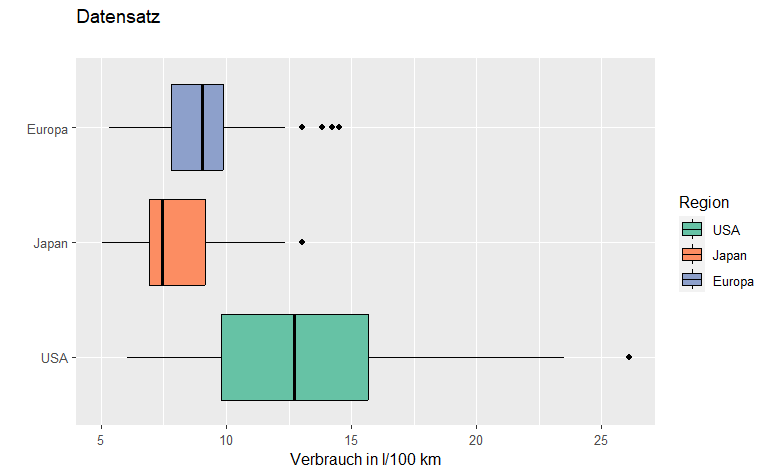

```r
ggplot(Auto,
       aes(x=Region, y=Verbrauch, fill=Region)) +
  geom_boxplot(color="black",
               outlier.colour = "black") +
  scale_fill_brewer(palette="Set2") +
  scale_x_discrete(limits=c("USA", "Japan", "Europa")) +
  labs(
    title="Datensatz",
    subtitle="",
    x = " ",
    y = "Verbrauch in l/100 km"
  ) +
  coord_flip()
```

Auch wenn wir bei Europa einige interessante Ausreißer sehen, bestätigt der Boxplot unsere These.

Wie finden wir diese Einträge mit europäischen Autos mit einem Verbrauch, der im Bereich des Medians für die US-amerikanischen Autos liegen. Wir berechnen den Median für die Gruppe der US-amerikansichen Autos und filtern alle europäischen Einträge mit diesem Wert. Das Ergebnis geben wir mit *datatable* aus.

```r
Mediane <- Auto %>%
  group_by(Region) %>%
  summarize(medians = median(Verbrauch))

USMedian <- Mediane$medians[1]

EUoutlier <- Auto %>%
  filter(Region=="Europa" & Verbrauch >= USMedian) %>%
  select(Name, Hubraum, Verbrauch) %>%
  mutate(across(is.numeric, round, digits = 1))

datatable(EUoutlier,
          options = list(pageLength = nrow(EUoutlier)))
```

|  | Name | Hubraum | Verbrauch |
| --- | --- | --- | --- |
| 1 | volvo 145e (sw) | 2 | 13.1 |
| 2 | mercedes-benz 280s | 2.8 | 14.2 |
| 3 | volvo 264gl | 2.7 | 13.8 |
| 4 | peugeot 604sl | 2.7 | 14.5 |

```r
NA
```

Wir finden zwei Modelle von Volvo, einen Mercedes-Benz und ein Modell von Peugeot mit relativ hohen Verbrauchswerten.

Eine These war, dass die Leistung in PS für immer größeren Hubraum immer größer wird. Das können wir mit Hilfe eines Streuungsdiagramms überprüfen:

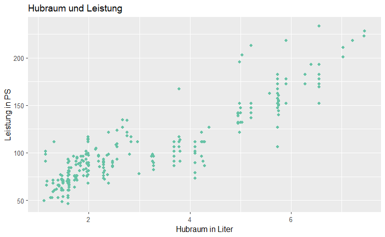

```r
ggplot(Auto, aes(x = Hubraum,
                  y = PS)) +
  geom_point(color = myPalette[1]) +
  labs(
    title="Hubraum und Leistung",
    x = "Hubraum in Liter",
    y = "Leistung in PS"
  )
```

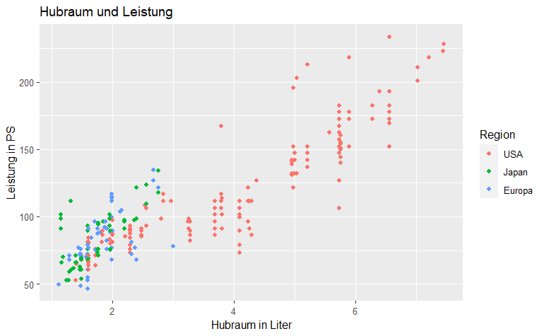

```r
ggplot(Auto, aes(x = Hubraum,
                 y = PS,
                 color = Region)) +
  geom_point() +
  labs(
    title="Hubraum und Leistung",
    x = "Hubraum in Liter",
    y = "Leistung in PS"
  )
```

Das Bild bestätigt unsere These visuell. Ab 3 Liter auf der x-Achse finden wir nur noch rote Punkte, die zu USA gehören.